# Q 1 Python data structures and other essentials

# Q 1.1 Tuples

1) Create the tuple named apps tuple with the string elements ”Google”, ”Facebook”, "Amazon”, ”Netflix”, ”AirBnB”, ”Instagram”.

```python
apps_tuple = ("Google", "Facebook", "Amazon", "Netflix", "AirBnB", "Instagram")
```

2) Extract the second element by using its index and the last element by using its negative index

```python
print(apps_tuple[1])
```

```
Facebook
```

```python
print(apps_tuple[-1])
```

```
Instagram
```

3) Slice the elements from ”Facebook” to ”Netflix” inclusive on both ends.

```python
print(apps_tuple[1:4])
```

```
('Facebook', 'Amazon', 'Netflix')
```

4) Try appending the element ”Messenger” to the tuple. What do you observe? Why?

```python
apps_tuple[6] = "Messenger"
```

```
---------------------------------------------------------------------------
TypeError                                 Traceback (most recent call last)
Input In [10], in <cell line: 1>()
----> 1 apps_tuple[6] = "Messenger"

TypeError: 'tuple' object does not support item assignment
```

```python
apps_tuple[5].append("Messenger")
```

```
---------------------------------------------------------------------------
AttributeError                            Traceback (most recent call last)
Input In [11], in <cell line: 1>()
----> 1 apps_tuple[5].append("Messenger")

AttributeError: 'str' object has no attribute 'append'
```

The main reason why we observe these errors are because tuples as well as strings are immutable.

# Q 1.2 Lists

1) Define the list apps list with the same elements as the tuple above.

```python
apps_list = ["Google", "Facebook", "Amazon", "Netflix", "AirBnB", "Instagram"]
```

2) Slice the first three elements of the list with the shorthand syntax, i.e. not by typing explicitly all the indexes 0, 1, and 2; use the symbol : instead.

```python
print(apps_list[:3])
```

```
['Google', 'Facebook', 'Amazon']
```

```python
print(apps_list[2:])
```

```
['Amazon', 'Netflix', 'AirBnB', 'Instagram']
```

4) Append the element ’Messenger’ to the end of the list and insert the element ’Youtube’ at index 1.

```python
apps_list.append("Messenger")
```

```python
apps_list.insert(1, "Youtube")
```

```python
apps_list
```

```
['Google',
 'Youtube',
 'Facebook',
 'Amazon',
 'Netflix',
 'AirBnB',
 'Instagram',
 'Messenger']
```

5) Remove element ’Facebook’ and confirm with the function in whether ’Facebook’ has been removed from the list.

```python
apps_list.remove("Facebook")
```

```python
"Facebook" in apps_list
```

```
False
```

```python
apps_list
```

```
['Google', 'Youtube', 'Amazon', 'Netflix', 'AirBnB', 'Instagram', 'Messenger']
```

6) Concatenate the last list with the list [’Linkedin’, ’Twitter’]

```python
apps_list + ["Linkedin", "Twitter"]
```

```
['Google',
 'Youtube',
 'Amazon',
 'Netflix',
 'AirBnB',
 'Instagram',
 'Messenger',
 'Linkedin',
 'Twitter']
```

# Q 1.3 Dicts

1) Create the dict named apps dict with the same values as in 1.1.1. and keys: app0, app1, etc.

```python
apps_dict = {"app0" : "Google",
             "app1" : "Facebook",
             "app2" : "Amazon",
             "app3" : "Netflix",
             "app4" : "AirBnB",
             "app5" : "Instagram"}
```

2) Access the element with key app1; then replace its value with ’Youtube’.

```python
apps_dict["app1"]
```

```
'Facebook'
```

```python
apps_dict["app1"] = "Youtube"
```

```python
apps_dict
```

```
{'app0': 'Google',
 'app1': 'Youtube',
 'app2': 'Amazon',
 'app3': 'Netflix',
 'app4': 'AirBnB',
 'app5': 'Instagram'}
```

3) Add a new key-value pair: app6-Messenger.

```python
apps_dict['app6'] = "Messenger"
```

```python
apps_dict
```

```
{'app0': 'Google',
 'app1': 'Youtube',
 'app2': 'Amazon',
 'app3': 'Netflix',
 'app4': 'AirBnB',
 'app5': 'Instagram',
 'app6': 'Messenger'}
```

4) What does the syntax: apps dict[”app1”]=”Messenger” do?

```python
apps_dict.update({"app1" : "Messenger"})
```

```python
apps_dict
```

```
{'app0': 'Google',
 'app1': 'Messenger',
 'app2': 'Amazon',
 'app3': 'Netflix',
 'app4': 'AirBnB',
 'app5': 'Instagram',
 'app6': 'Messenger'}
```

```python
#This converted the value of "app1", previously "Youtube", to "Messenger".
```

5) What does the syntax: apps dict[”App1”]=”Facebook” do? Why?

```python
apps_dict["App1"] = "Facebook"
```

```python
apps_dict
```

```
{'app0': 'Google',
 'app1': 'Messenger',
 'app2': 'Amazon',
 'app3': 'Netflix',
 'app4': 'AirBnB',
 'app5': 'Instagram',
 'app6': 'Messenger',
 'App1': 'Facebook'}
```

```python
#It adds the new "App1" as a "Key" and "Value" to the bottom, becacuse it is in the format of a "key" and "value".
```

6) What does the syntax: del apps dict[”App1”] do?

```python
del apps_dict["App1"]
```

```python
apps_dict
```

```
{'app0': 'Google',
 'app1': 'Messenger',
 'app2': 'Amazon',
 'app3': 'Netflix',
 'app4': 'AirBnB',
 'app5': 'Instagram',
 'app6': 'Messenger'}
```

```python
# It deletes the "App1" key and value just by recalling the "Key".
```

# Q 1.4 List Comprehension

1) Create the list named values with integers: 7, 12, 9, 18, 15.

```python
values = [7,12,9,18,15]
```

```python
values
```

```
[7, 12, 9, 18, 15]
```

2) Create a list comprehension that takes the object values and returns the square of every value.

```python
[num**2 for num in values]
```

```
[49, 144, 81, 324, 225]
```

# Q 1.5 Functions and control flow

1) Generate a sample of 10 random integer numbers between 600 and 900 (hint: use Numpy’s random integers function).

```python
import numpy as n
```

```python
n.random.randint(low=600, high=900, size=10, dtype=int)
```

```
array([665, 638, 634, 861, 699, 805, 771, 775, 799, 642])
```

2) Create a function called credit score that reads the sample and returns the output ’Low’ when the input is [600, 699], ’Medium’ when in [700, 799] and ’High’ when in [800, 900].

```python
R = n.random.randint(low=600, high=900, size=10, dtype=int)
```

```python
R
```

```
array([812, 652, 797, 789, 737, 665, 658, 885, 611, 662])
```

```python
def credit_score(sample):
    if sample >= 600 and sample <= 699:
        return 'Low'
    elif sample >= 700 and sample <= 799:
        return 'Medium'
    elif sample >= 800 and sample <= 900:
        return 'High'

for sample in R:
    print(credit_score(sample))
```

```
High
Low
Medium
Medium
Medium
Low
Low
High
Low
Low
```

# Q 2 Linear algebra in Numpy

```python
import numpy as n
```

# Q 2.1 Matrix calculations

1) Create matrices A and B as numpy arrays and calculate 2A, -3B and A+B

```python
A = n.array([[2,1],
             [1,1],
             [2,3]])
```

```python
B = n.array([[-4,1],
            [3,-1],
            [-2,1]])
```

```python
A*2
```

```
array([[4, 2],
       [2, 2],
       [4, 6]])
```

```python
B*-3
```

```
array([[12, -3],
       [-9,  3],
       [ 6, -3]])
```

```python
A+B
```

```
array([[-2,  2],
       [ 4,  0],
       [ 0,  4]])
```

2) Create matrices A and B as numpy arrays and calculate A*B and the inverse of B

```python
A = n.array([[2,-6],
             [-4,0],
             [1,5]])
```

```python
B = n.array([[1,1],
             [2,3]])
```

```python
A @ B
```

```
array([[-10, -16],
       [ -4,  -4],
       [ 11,  16]])
```

```python
n.linalg.inv(B)
```

```
array([[ 3., -1.],
       [-2.,  1.]])
```

3) Replace the values of the elements with abs(value)≥3 with the value 3. Also, calculate the determinant of the original matrix A.

```python
A[2,1] = 3
```

```python
A
```

```
array([[ 2, -6],
       [-4,  0],
       [ 1,  3]])
```

```python
A = n.array([[1,0,4,1],
             [-2,1,-3,2],
             [0,0,0,2],
             [3,2,1,-1]])
```

```python
n.linalg.det(A)
```

```
42.00000000000001
```

# Q 2.2 Norms and eigenvlaues

1) Calculate the maximum and Euclidean or Frobenius norm of each of the three vectors:

```python
x1 = n.array([1,-2,3])
```

```python
x2 = n.array([2,0,-1,2])
```

```python
x3 = n.array([0,1,-4,2,-1])
```

```python
#Maximums
```

```python
n.max(x1)
```

```
3
```

```python
n.max(x2)
```

```
2
```

```python
n.max(x3)
```

```
2
```

```python
#Frobenius norms
```

```python
n.linalg.norm(x1,2)
```

```
3.7416573867739413
```

```python
n.linalg.norm(x2,2)
```

```
3.0
```

```python
n.linalg.norm(x3,2)
```

```
4.69041575982343
```

2) Calculate the l2 and l∞ norms of the matrices:

```python
from numpy import inf
```

```python
A1 = n.array([[1,-2],
              [4,3]])
```

```python
n.linalg.norm(A1,2)
```

```
5.0197648378370845
```

```python
n.linalg.norm(A1,inf)
```

```
7.0
```

```python
A2 = n.array([[1,0,2],
              [0,1,-1],
              [-1,1,1]])
```

```python
n.linalg.norm(A2,2)
```

```
2.4998281017161057
```

```python
n.linalg.norm(A2,inf)
```

```
3.0
```

3) Calculate the eigenvalues of the matrix:

```python
A = n.array([[-2,-2,3],
             [-10,-1,6],
             [10,-2,-9]])
```

```python
n.linalg.eigvals(A)
```

```
array([-12.,   3.,  -3.])
```

# Q 3 Pandas Manipulations

```python
import pandas as pd
```

```python
import warnings
warnings.filterwarnings('ignore')
```

```python
df = pd.read_excel("Gas_prices.xlsx")
df.head(100)
```

|  | Date | Price_pl |
| --- | --- | --- |
| 0 | 12/11/2015 | 1.049 |
| 1 | 19/11/2015 | 0.999 |
| 2 | 7/12/2015 | 0.999 |
| 3 | 19/12/2015 | 1.019 |
| 4 | 04/01/2016 | 1.019 |
| ... | ... | ... |
| 77 | 17/10/2018 | 1.209 |
| 78 | 01/11/2018 | 1.196 |
| 79 | 12/11/2018 | 1.126 |
| 80 | 27/11/2018 | 1.059 |
| 81 | 06/12/2018 | 1.016 |

82 rows × 2 columns

```python
df.loc[5][1]
```

```
0.959
```

```python
len(df)
```

```
82
```

1) Import file Gas prices.xls as a pandas DataFrame. Create a function that replaces NaN with the interpolation between the adjacent values (i.e. the prior and the subsequent to the NaN). Do not use existing interpolation functions, built your own.

```python
df1 = df.copy()

def interpolate():
    check_nan = df1['Price_pl'].isnull()
    count = -1
    for i in check_nan:
        count += 1
        if i is True:
            avg = (df1['Price_pl'][count-1] + df1['Price_pl'][count+1]) / 2
#             print(count)
#             print(avg)
            df1.at[count, 'Price_pl'] = avg
    return df1


df = interpolate()
df.head(15)
```

[output not shown]

2) Find the index, the date and the value of the min and max gas price.

```python
min_index = df['Price_pl'].idxmin()
print("Minimum Index :", min_index)
print("Minimum Value Date :", df.loc[min_index][0])
print("Minimum Value :", df.loc[min_index][1])
print('\n')

max_index = df['Price_pl'].idxmax()
print("Maximum Index :", max_index)
print("Maximum Value Date :", df.loc[max_index][0])
print("Maximum Value :", df.loc[max_index][1])
```

```
Minimum Index : 9
Minimum Value Date : 20/2/2016
Minimum Value : 0.889


Maximum Index : 73
Maximum Value Date : 23/05/2018
Maximum Value : 1.336
```

3) Calculate the following descriptive statistics: mean, median, quantile, skewness and kurtosis

```python
print("Mean : ", df['Price_pl'].mean())
print("Median : ", df['Price_pl'].median())
print("Quantile : ", df['Price_pl'].quantile())
print("Skewness : ", df['Price_pl'].skew(skipna=True))
print("kurtosis : ", df['Price_pl'].kurt())
```

```
Mean :  1.0953902439024386
Median :  1.079
Quantile :  1.079
Skewness :  0.46752591499730667
kurtosis :  -0.257963187132765
```

```python
import datetime

df['Year'] = pd.DatetimeIndex(df['Date']).year
df['Month'] = pd.DatetimeIndex(df['Date']).month

df.head()
```

|  | Date | Price_pl | Year | Month |
| --- | --- | --- | --- | --- |
| 0 | 12/11/2015 | 1.049 | 2015 | 12 |
| 1 | 19/11/2015 | 0.999 | 2015 | 11 |
| 2 | 7/12/2015 | 0.999 | 2015 | 7 |
| 3 | 19/12/2015 | 1.019 | 2015 | 12 |
| 4 | 04/01/2016 | 1.019 | 2016 | 4 |

```python
Month = pd.pivot_table(df, index=['Month'])
Month
```

| Month | Price_pl | Year |
| --- | --- | --- |
| 1 | 1.065714 | 2016.714286 |
| 2 | 1.115150 | 2017.100000 |
| 3 | 1.126250 | 2017.125000 |
| 4 | 1.138357 | 2016.857143 |
| 5 | 1.101429 | 2016.571429 |
| 6 | 1.066125 | 2016.750000 |
| 7 | 1.089000 | 2016.500000 |
| 8 | 1.062333 | 2016.666667 |
| 9 | 1.101333 | 2016.833333 |
| 10 | 1.092143 | 2016.714286 |
| 11 | 1.027800 | 2016.400000 |
| 12 | 1.124429 | 2016.428571 |

```python
Year = pd.pivot_table(df, columns=['Year'])
Year
```

| Year | 2015 | 2016 | 2017 | 2018 |
| --- | --- | --- | --- | --- |
| Month | 10.5000 | 6.125000 | 5.807692 | 5.600000 |
| Price_pl | 1.0165 | 1.010609 | 1.112462 | 1.224625 |

5) Create a new column with the season of the year, set it as a secondary index and calculate the average of every season (regardless of the year) to create the following table:

```python
data = [['Fall', 0], ['Winter', 0], ['Spring', 0], ['Summer', 0]]
final = pd.DataFrame(data, columns=['Season', 'Average price ($)'])
final = pd.pivot_table(final, index=['Season'])
final
```

| Season | Average price ($) |
| --- | --- |
| Fall | 0 |
| Spring | 0 |
| Summer | 0 |
| Winter | 0 |

```python
final.at['Fall', 'Average price ($)'] = (Month.loc[9]['Price_pl'] + Month.loc[10]['Price_pl'] + Month.loc[11]['Price_pl'])/3
final.at['Spring', 'Average price ($)'] = (Month.loc[3]['Price_pl'] + Month.loc[4]['Price_pl'] + Month.loc[5]['Price_pl'])/3
final.at['Summer', 'Average price ($)'] = (Month.loc[6]['Price_pl'] + Month.loc[7]['Price_pl'] + Month.loc[8]['Price_pl'])/3
final.at['Winter', 'Average price ($)'] = (Month.loc[12]['Price_pl'] + Month.loc[1]['Price_pl'] + Month.loc[2]['Price_pl'])/3


final
```

| Season | Average price ($) |
| --- | --- |
| Fall | 1.073759 |
| Spring | 1.122012 |
| Summer | 1.072486 |
| Winter | 1.101764 |

# Q 4 Pivot, aggregate and plot timeseries

```python
import pandas as pd
```

```python
import warnings
warnings.filterwarnings('ignore')
```

```python
df = pd.read_excel("TREB_data.xlsx")
df.head()
```

|  | MonthYear | Sales | AveragePrice |
| --- | --- | --- | --- |
| 0 | January-2017 | 5155 | 768351 |
| 1 | February-2017 | 7955 | 876363 |
| 2 | March-2017 | 11959 | 915353 |
| 3 | April-2017 | 11470 | 918138 |
| 4 | May-2017 | 10068 | 862109 |

1) Create the necessary columns to pivot and generate the table below with the value of Sales (hint: use the split() function to split the MonthYear column to Month and Year).

```python
df.dtypes
```

```
MonthYear       object
Sales            int64
AveragePrice     int64
dtype: object
```

```python
df[['Month','Year']] = df['MonthYear'].str.split('-', expand=True)
df.drop(columns =["MonthYear"], inplace = True)
```

```python
df1 = pd.pivot_table(data=df,
                        index=['Month'],
                        columns=['Year'],
                        values='Sales',)

df1
```

| Year Month | 2013 | 2014 | 2015 | 2016 | 2017 |
| --- | --- | --- | --- | --- | --- |
| April | 9537 | 9660 | 11254 | 12016 | 11470 |
| August | 7390 | 7568 | 7943 | 9748 | 6310 |
| December | 4058 | 4418 | 4917 | 5305 | 4930 |
| February | 5615 | 5696 | 6294 | 7582 | 7955 |
| January | 4230 | 4103 | 4318 | 4640 | 5155 |
| July | 8367 | 9152 | 9813 | 9929 | 5871 |
| June | 8821 | 10132 | 11905 | 12725 | 7896 |
| March | 7536 | 8052 | 8886 | 10260 | 11959 |
| May | 9945 | 11013 | 11640 | 12789 | 10068 |
| November | 6354 | 6475 | 7337 | 8503 | 7353 |
| October | 7940 | 8512 | 8759 | 9715 | 7087 |
| September | 7256 | 8001 | 8147 | 9828 | 6340 |

```python
new_order = ['January', 'February', 'March', 'April', 'May', 'June', 'July', 'August', 'September', 'October', 'November', 'December']

df1 = df1.reindex(new_order, axis=0)
df1
```

| Year Month | 2013 | 2014 | 2015 | 2016 | 2017 |
| --- | --- | --- | --- | --- | --- |
| January | 4230 | 4103 | 4318 | 4640 | 5155 |
| February | 5615 | 5696 | 6294 | 7582 | 7955 |
| March | 7536 | 8052 | 8886 | 10260 | 11959 |
| April | 9537 | 9660 | 11254 | 12016 | 11470 |
| May | 9945 | 11013 | 11640 | 12789 | 10068 |
| June | 8821 | 10132 | 11905 | 12725 | 7896 |
| July | 8367 | 9152 | 9813 | 9929 | 5871 |
| August | 7390 | 7568 | 7943 | 9748 | 6310 |
| September | 7256 | 8001 | 8147 | 9828 | 6340 |
| October | 7940 | 8512 | 8759 | 9715 | 7087 |
| November | 6354 | 6475 | 7337 | 8503 | 7353 |
| December | 4058 | 4418 | 4917 | 5305 | 4930 |

2) In one figure, plot 5 lines (one line per year) with the monthly sales versus the month of the year.

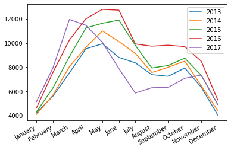

```python
import matplotlib.pyplot as plt

plt.plot(df1.iloc[:, 0], label = "2013")
plt.plot(df1.iloc[:, 1], label = "2014")
plt.plot(df1.iloc[:, 2], label = "2015")
plt.plot(df1.iloc[:, 3], label = "2016")
plt.plot(df1.iloc[:, 4], label = "2017")
plt.legend()
plt.gcf().autofmt_xdate()
plt.show()
```

3) Calculate the total Sales per year and create a bar chart. Do this in two different ways: a) group by year the table pre-pivoting, b) summing up the five columns post-pivoting

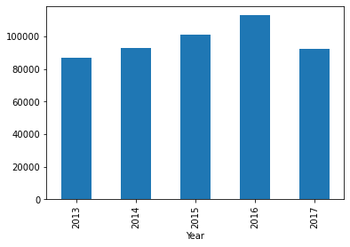

```python
# before pivot

df1 = df.groupby("Year")["Sales"].sum()
df1.plot.bar()
```

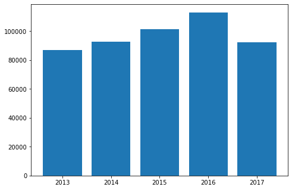

```python
# after pivot

import matplotlib.pyplot as plt

df3 = pd.pivot_table(data=df,
                        columns=['Year'],
                        values='Sales',
                        aggfunc='sum')
df3

fig = plt.figure()
ax = fig.add_axes([0,0,1,1])
X = list(df3.columns)
Y = list(df3.iloc[0])
ax.bar(X,Y)
plt.show()
```

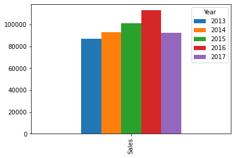

```python
import numpy as np
import matplotlib.pyplot as plt

df3.plot.bar()
```